# DS Project

- Show All Code
- Hide All Code
- View Source

Author

Lucas Rapeepat, Ian Stripe

# Introduction

In the contemporary landscape of American family life, the cost of childcare emerges as a pivotal factor influencing economic stability, parental employment, and, ultimately, child welfare. Access to affordable, quality childcare has been linked to a range of positive outcomes, including increased workforce participation, particularly among women, and enhanced child development. Yet, for many families across the United States, childcare remains a significant financial burden, absorbing a disproportionate share of household income. This project seeks to illuminate the complexities surrounding childcare costs, shedding light on their variability across different geographical regions and over time.

This analysis is anchored in data drawn from the National Database of Childcare Prices, the most comprehensive federal repository of childcare price information at the county level. Spanning from 2008 to 2018, this database offers a granular look at childcare costs across various dimensions: by provider type, the age of children, and county characteristics. The project utilizes two primary data sets: childcare_costs.csv, containing detailed childcare price data, and counties.csv, which provides a suite of county-level attributes. These datasets are unified through the county_fips_code, enabling a holistic examination of how childcare costs correlate with a myriad of socioeconomic factors.

The goal of this project is not merely to chart the ebb and flow of childcare expenses but to understand the broader implications of these costs on families and communities. By employing a robust analytical framework, this study will explore several key questions: How have childcare costs evolved over the last decade? Do these costs exhibit significant variability across states or regions? What socioeconomic variables—such as unemployment rates, median household income, or racial composition—interact most dynamically with childcare expenses?

The answers to these questions promise not only to advance our understanding of childcare economics but also to inform policy discussions aimed at making quality childcare more accessible and affordable. Through a meticulous analysis of available data, this project endeavors to contribute a meaningful voice to the ongoing dialogue about how best to support American families in balancing the demands of work and child-rearing.

# Section 2

```r
library(tidyverse)
library(DT)
```

```r
# Load and inspect the datasets
childcare_costs <- read.csv("C:/Users/Lucas Rapeepat/Downloads/childcare_costs.csv")
counties <- read.csv("C:/Users/Lucas Rapeepat/Downloads/counties.csv")
str(childcare_costs)
str(counties)

# Size of data pre-merge
dim(childcare_costs)
dim(counties)


# Merge datasets
combined_data <- childcare_costs |>
  inner_join(counties, by = "county_fips_code")

# Remove missing data
cleaned_data <- combined_data |>
  drop_na()

#Counting Counties
cleaned_data |>
  select(county_name) |>
  n_distinct(na.rm = TRUE)

#Dim Cleaned Data

dim(cleaned_data)
```

[output not shown]

## Data Pre-Processing

In the Data Pre-Processing section of our report, we initiated our in-depth analysis with an extensive review of the two core datasets at our disposal: childcare_costs.csv and counties.csv. The childcare_costs file was a rich repository, with tens of thousands of rows encapsulating crucial childcare pricing data. The counties dataset, while not as extensive, provided essential demographic and socioeconomic indicators for each county.

We merged the childcare_costs and counties datasets on the county_fips_code, which acted as a unique identifier for each county, and ensured that only records with matching identifiers in both datasets were retained.

The dimensions of the raw childcare costs data before merging are 34567 by 61, while the dimensions of the counties table are 3144 by 4. After the merge, the dimensions of the cleaned data are 23342 by 64.

There are 1779 unique counties available for analysis, which we counted from the cleaned and joined dataset.

# Section 3

Descriptive Statistics for childcare and family costs:

```r
# Calculate descriptive statistics for the different childcare costs
descstats <- cleaned_data |>
  select(mcsa, mfccsa) |>
  summarise_all(list(mean = mean, median = median, IQR = IQR), na.rm = TRUE)

datatable(descstats,
          caption = "Table 1: Descriptive Stats for Childcare Costs",
          colnames = c("Number", "Center-Based Mean", "Family-Based Mean", "Center-Based Median", "Family-Based Median", "Center-Based IQR", "Family-Based IQR")


)
```

| Number | Center-Based Mean | Family-Based Mean | Center-Based Median | Family-Based Median | Center-Based IQR | Family-Based IQR |
| --- | --- | --- | --- | --- | --- | --- |
| 1 | 101.194717676292 | 92.469410933082 | 96.5 | 88.05 | 40.8475 | 32.48 |

Grouping highest costs by county

```r
countycosts <- cleaned_data |>
  group_by(county_name) |>
  summarize(
    childcare_avg = mean(mcsa, na.rm = TRUE),
    family_avg = mean(mfccsa, na.rm = TRUE)
  ) |>
  arrange(desc(childcare_avg)) |>
  slice_head(n = 5)

datatable(countycosts,
          caption = "Table 2: County Costs",
          colnames = c("County Name", "Childcare Average", "Family Average")

)
```

|  | County Name | Childcare Average | Family Average |
| --- | --- | --- | --- |
| 1 | Rockland County | 313.96 | 271.39 |
| 2 | Westchester County | 305.41 | 262.13 |
| 3 | Arlington County | 292.5 | 228.1 |
| 4 | Pitkin County | 281.8 | 186.44 |
| 5 | Routt County | 281.8 | 186.44 |

Did childcare costs differ by state (on average)?

```r
state_costs <- cleaned_data |>
  group_by(state_name) |>
  summarize(across(starts_with("mc"), mean, na.rm = TRUE))

datatable(
  state_costs,
  caption = "Table 3: Costs by State",
  colnames = c("Number", "State", "Center-Based", "Infant", "Toddler", "Preschooler")
)
```

| Number | State | Center-Based | Infant | Toddler | Preschooler |
| --- | --- | --- | --- | --- | --- |
| 1 | Alabama | 92.2466621438263 | 105.752957937585 | 105.752957937585 | 96.7932157394844 |
| 2 | Alaska | 166.591333333333 | 201.884 | 196.558666666667 | 166.192666666667 |
| 3 | Arizona | 119.649151515152 | 164.568545454545 | 145.969878787879 | 132.493818181818 |
| 4 | Arkansas | 82.7833333333333 | 104.916666666667 | 100.550666666667 | 92.25 |
| 5 | California | 159.427570532915 | 270.840031347962 | 193.976003134796 | 193.976003134796 |
| 6 | Colorado | 169.8203125 | 226.0859375 | 199.9875 | 176.1125 |
| 7 | Connecticut | 93.1677272727273 | 253.238636363636 | 253.238636363636 | 211.048409090909 |
| 8 | Delaware | 71.2339393939394 | 175.593333333333 | 156.917878787879 | 143.138787878788 |
| 9 | District of Columbia | 248.63 | 303.58 | 253.06 | 237.78 |
| 10 | Florida | 95.5900949367089 | 145.455094936709 | 123.436170886076 | 111.43253164557 |

[output cut: 39 more lines]

How were childcare costs related by race?

```r
library(dplyr)

# Calculate weighted averages for each race and childcare type
race_weighted_costs <- cleaned_data |>
  summarize(
    white_infant = weighted.mean(mc_infant, one_race_w, na.rm = TRUE),
    black_infant = weighted.mean(mc_infant, one_race_b, na.rm = TRUE),
    native_infant = weighted.mean(mc_infant, one_race_i, na.rm = TRUE),
    asian_infant = weighted.mean(mc_infant, one_race_a, na.rm = TRUE),
    islander_infant = weighted.mean(mc_infant, one_race_h, na.rm = TRUE),
    other_infant = weighted.mean(mc_infant, one_race_other, na.rm = TRUE),

    white_toddler = weighted.mean(mc_toddler, one_race_w, na.rm = TRUE),
    black_toddler = weighted.mean(mc_toddler, one_race_b, na.rm = TRUE),
    native_toddler = weighted.mean(mc_toddler, one_race_i, na.rm = TRUE),
    asian_toddler = weighted.mean(mc_toddler, one_race_a, na.rm = TRUE),
    islander_toddler = weighted.mean(mc_toddler, one_race_h, na.rm = TRUE),
    other_toddler = weighted.mean(mc_toddler, one_race_other, na.rm = TRUE),

    white_preschool = weighted.mean(mc_preschool, one_race_w, na.rm = TRUE),
    black_preschool = weighted.mean(mc_preschool, one_race_b, na.rm = TRUE),
    native_preschool = weighted.mean(mc_preschool, one_race_i, na.rm = TRUE),
    asian_preschool = weighted.mean(mc_preschool, one_race_a, na.rm = TRUE),
    islander_preschool = weighted.mean(mc_preschool, one_race_h, na.rm = TRUE),
    other_preschool = weighted.mean(mc_preschool, one_race_other, na.rm = TRUE)
  )

# Transform data to have races as rows and childcare cost denominations as columns
race_weighted_costs_long <- race_weighted_costs |>
  pivot_longer(
    everything(),
    names_to = c(".value", "childcare_type"),
    names_pattern = "(.*)_(.*)"
  )


datatable(
  race_weighted_costs_long,
  caption = "Table 4: Costs by Race",
  colnames = c("Childcare Type", "White", "Black", "Native American", "Asian", "Pacific Islander", "Other")
)
```

|  | Childcare Type | White | Black | Native American | Asian | Pacific Islander | Other |
| --- | --- | --- | --- | --- | --- | --- | --- |
| 1 | infant | 145.643547195202 | 132.47855778616 | 134.551863514379 | 205.823771538294 | 179.030800570262 | 163.780605115773 |
| 2 | toddler | 130.396339061122 | 117.801742691743 | 120.598229383828 | 175.06672233266 | 154.022500664226 | 141.58475672855 |
| 3 | preschool | 122.099767474772 | 111.29651102761 | 114.594787324193 | 163.307633497136 | 141.52508375725 | 132.714208484575 |

Comparison of Family Care vs Center-Based

```r
# Calculate the average costs for center-based and family childcare for each age group
care_cost_comparison <- cleaned_data |>
  summarize(
    avg_center_infant = mean(mc_infant, na.rm = TRUE),
    avg_family_infant = mean(mfcc_infant, na.rm = TRUE),
    avg_center_toddler = mean(mc_toddler, na.rm = TRUE),
    avg_family_toddler = mean(mfcc_toddler, na.rm = TRUE),
    avg_center_preschool = mean(mc_preschool, na.rm = TRUE),
    avg_family_preschool = mean(mfcc_preschool, na.rm = TRUE)
  )

datatable (care_cost_comparison,
           caption = "Table 5: Comparison of Center-Based and Family Costs",
           colnames = c("Average Center Infant", "Average Family Infant", "Average Center Toddler", "Average Family Toddler", "Average Center Preschool", "Average Family Preschool")

)
```

|  | Average Center Infant | Average Family Infant | Average Center Toddler | Average Family Toddler | Average Center Preschool | Average Family Preschool |
| --- | --- | --- | --- | --- | --- | --- |
| 1 | 145.69537186188 | 113.388566532431 | 130.09411490018 | 106.723177962471 | 121.927485219776 | 104.153132550767 |

Childcare Costs related to Poverty Rates?

```r
#Lowest 5 Poverty Rates
lowpoverty <- cleaned_data |>
  select(pr_f, mc_infant, mc_toddler, mc_preschool, mfcc_infant, mfcc_toddler, mfcc_preschool) |>
  arrange(pr_f) |>
  slice_head(n = 5)

datatable(lowpoverty,
          caption = "Table 6: Lowest Poverty Rates",
          colnames = c("Poverty Rate", "Center-Based Infant", "Center-Based Toddler", "Center-Based Preschool", "Family-Based Infant", "Family-Based Toddler", "Family-Based Preschool"
          )

)
```

|  | Poverty Rate | Center-Based Infant | Center-Based Toddler | Center-Based Preschool | Family-Based Infant | Family-Based Toddler | Family-Based Preschool |
| --- | --- | --- | --- | --- | --- | --- | --- |
| 1 | 0 | 132.79 | 119.96 | 108.45 | 120.01 | 114.76 | 111.62 |
| 2 | 0 | 123.32 | 111.41 | 100.72 | 111.45 | 106.58 | 103.66 |
| 3 | 0 | 102.6 | 95.15 | 89.13 | 91.32 | 85.73 | 81.68 |
| 4 | 0 | 108.3 | 100.15 | 93.2 | 94.95 | 89.9 | 86.25 |
| 5 | 0 | 155.25 | 141.15 | 129.5 | 133.8 | 126.25 | 118.55 |

```r
#Highest 5 Poverty Rates
highpoverty <- cleaned_data |>
  select(pr_f, mc_infant, mc_toddler, mc_preschool, mfcc_infant, mfcc_toddler, mfcc_preschool) |>
  arrange(desc(pr_f)) |>
  slice_head(n = 5)

datatable(highpoverty,
          caption = "Table 7: Highest Poverty Rates",
          colnames = c("Poverty Rate", "Center-Based Infant", "Center-Based Toddler", "Center-Based Preschool", "Family-Based Infant", "Family-Based Toddler", "Family-Based Preschool"
                       ))
```

|  | Poverty Rate | Center-Based Infant | Center-Based Toddler | Center-Based Preschool | Family-Based Infant | Family-Based Toddler | Family-Based Preschool |
| --- | --- | --- | --- | --- | --- | --- | --- |
| 1 | 52.1 | 103.4 | 103.4 | 100.82 | 86.17 | 86.17 | 86.17 |
| 2 | 49.8 | 103.4 | 103.4 | 98.23 | 86.17 | 86.17 | 86.17 |
| 3 | 49.4 | 99.09 | 99.09 | 94.79 | 81.86 | 81.86 | 81.86 |
| 4 | 48.8 | 103.4 | 103.4 | 98.23 | 86.17 | 86.17 | 86.17 |
| 5 | 45.5 | 94.79 | 94.79 | 91.34 | 77.55 | 77.55 | 76.69 |

Childcare Costs in Counties with High Service Sector Employment Determine if counties with a higher proportion of service sector employment see different childcare costs.

```r
 service <- cleaned_data |>
  filter(emp_service > median(emp_service, na.rm = TRUE)) |>
  summarise(
    median_cost_infant = median(mc_infant, na.rm = TRUE),
    median_cost_toddler = median(mc_toddler, na.rm = TRUE),
    median_cost_preschool = median(mc_preschool, na.rm = TRUE)
  )

datatable (
  service,
  caption = "Table 8: Costs in High Service Sector Employment Counties",
  colnames = c("Number", "Median Infant Cost", "Median Cost Toddler", "Median Cost Preschool")
)
```

| Number | Median Infant Cost | Median Cost Toddler | Median Cost Preschool |
| --- | --- | --- | --- |
| 1 | 136.13 | 122.95 | 115 |

To delve deeper, we examined the counties with the highest average childcare costs. By grouping and summarizing the data by county, and then arranging the results in descending order, we identified counties like Rockland and Westchester in New York, which showed exceptionally high childcare expenses. This regional variability underscores the geographical disparities in childcare affordability.

Further analysis explored how childcare costs varied by state, using a grouped summary across states that calculated the mean for various childcare-related expenses. This state-level breakdown revealed substantial differences, reflecting the socio-economic and policy landscape that significantly impacts childcare costs across the United States.

The relationship between childcare costs and race was also investigated. By calculating weighted averages for childcare costs across different racial demographics and childcare types (infant, toddler, preschool), we observed that costs vary notably by race, with Asian families typically facing higher expenses. This points to potential systemic inequalities that might affect access to childcare services based on racial lines.

A comparison of family care versus center-based care costs showed that, on average, center-based care is more expensive across all age groups. This comparison is crucial for families making decisions between these two types of childcare based on their financial capabilities.

Additionally, we looked at how childcare costs correlate with poverty rates by examining counties with the lowest and highest poverty rates. This analysis highlighted that higher poverty rates do not always correlate with lower childcare costs, suggesting that even economically disadvantaged families face high childcare expenses, which could exacerbate financial strain.

Lastly, we assessed whether counties with a higher proportion of service sector employment experienced different childcare costs. The findings indicated that these counties did not necessarily enjoy lower childcare costs, which could imply that employment in service sectors does not benefit from proximity to more affordable childcare solutions.

# Section 4

Did childcare costs (by age group) on average change over time from 2008 to 2018?

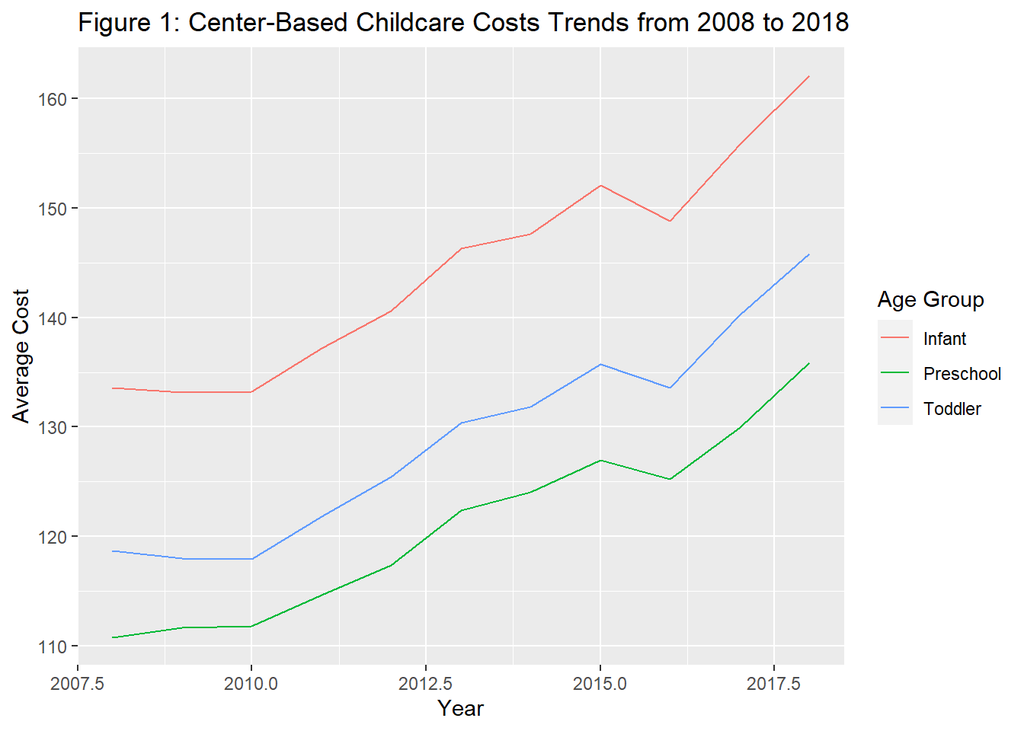

```r
cost_trends <- cleaned_data |>
  select(study_year, mc_infant, mc_toddler, mc_preschool) |>
  group_by(study_year) |>
  summarize(across(starts_with("mc"), mean, na.rm = TRUE))

ggplot(cost_trends, aes(x = study_year)) +
  geom_line(aes(y = mc_infant, color = "Infant")) +
  geom_line(aes(y = mc_toddler, color = "Toddler")) +
  geom_line(aes(y = mc_preschool, color = "Preschool")) +
  labs(title = "Figure 1: Center-Based Childcare Costs Trends from 2008 to 2018",
       x = "Year",
       y = "Average Cost",
       color = "Age Group")
```

How were Childcare costs related to Median Household Income?

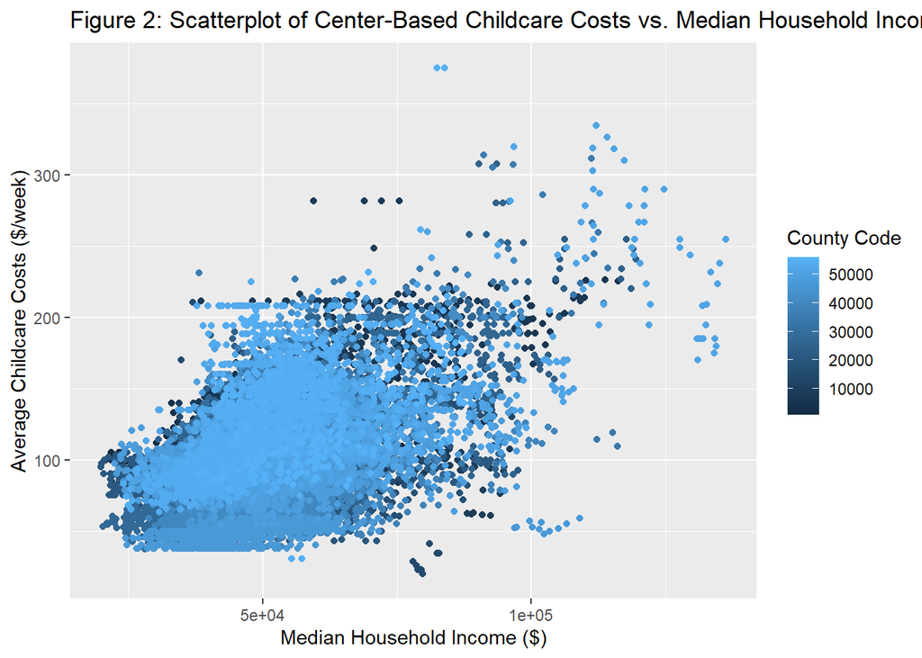

```r
ggplot(cleaned_data, aes(x = mhi_2018, y = mcsa)) +
  geom_point(aes(color = county_fips_code)) +
  labs(title = "Figure 2: Scatterplot of Center-Based Childcare Costs vs. Median Household Income",
       x = "Median Household Income ($)",
       y = "Average Childcare Costs ($/week)",
       color = "County Code"
    )
```

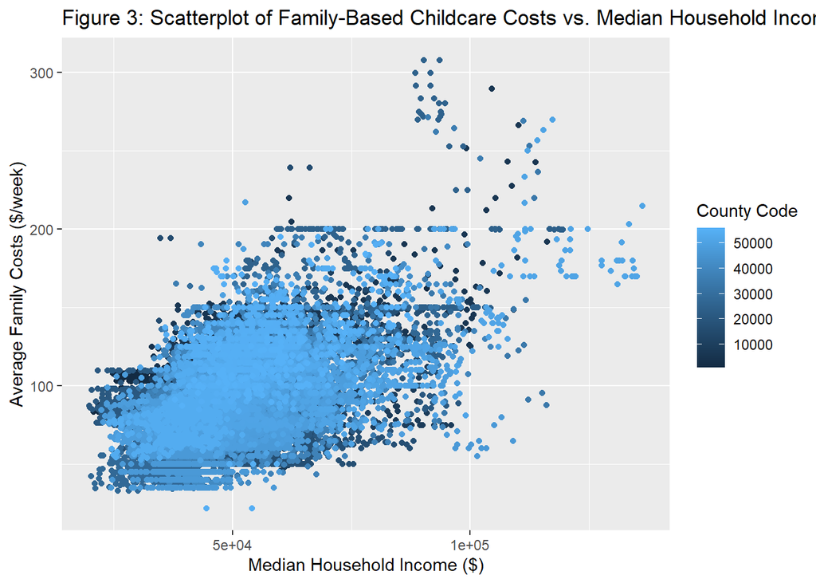

```r
ggplot(cleaned_data, aes(x = mhi_2018, y = mfccsa)) +
  geom_point(aes(color = county_fips_code)) +
  labs(title = "Figure 3: Scatterplot of Family-Based Childcare Costs vs. Median Household Income",
       x = "Median Household Income ($)",
       y = "Average Family Costs ($/week)",
       color = "County Code"
    )
```

This scatterplot displays the relationship between median household income and average weekly childcare costs. There is a slight positive correlation between median household income and average childcare costs.There is a similar correlation between family care and median household income, which is to be expected, as wealthier households can afford to spend more in raising their children.

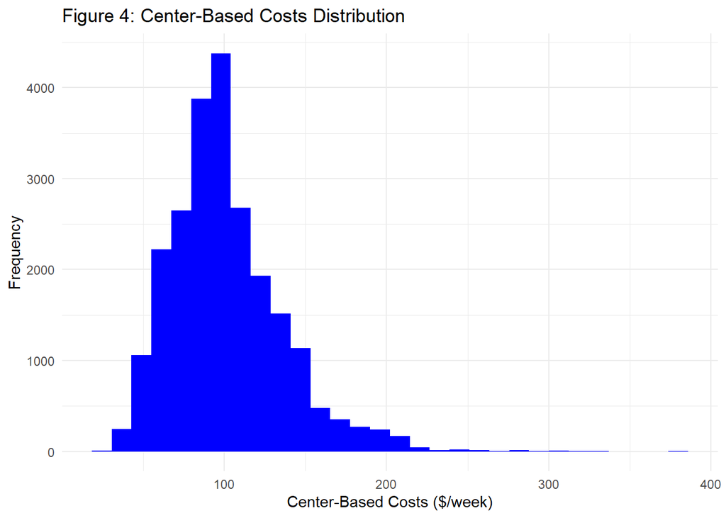

```r
ggplot(cleaned_data, aes(x = mcsa)) +
  geom_histogram(bins = 30, fill = "blue") +
  labs(title = "Figure 4: Center-Based Costs Distribution",
       x = "Center-Based Costs ($/week)",
       y = "Frequency") +
  theme_minimal()
```

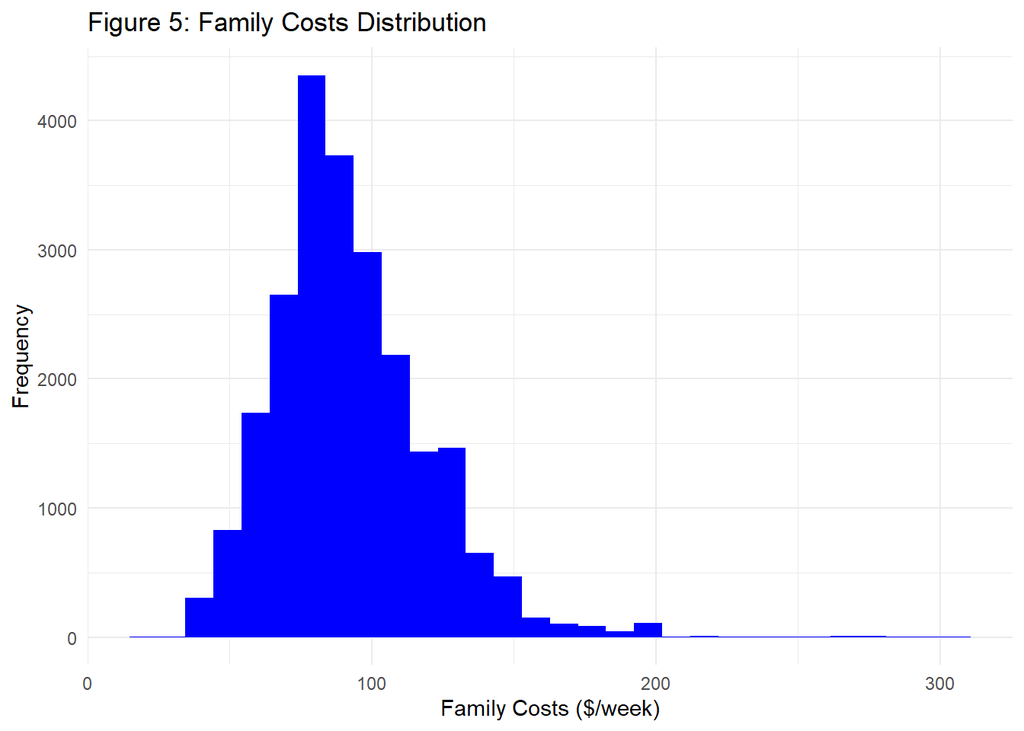

```r
ggplot(cleaned_data, aes(x = mfccsa)) +
  geom_histogram(bins = 30, fill = "blue") +
  labs(title = "Figure 5: Family Costs Distribution",
       x = "Family Costs ($/week)",
       y = "Frequency") +
  theme_minimal()
```

This histogram shows the distribution of weekly childcare costs, both in center-based and family. The shape and spread of the distribution provide insights into the common cost ranges and the variability of childcare expenses. The distributions are pretty similar, with the median falling around the $100 a week range.

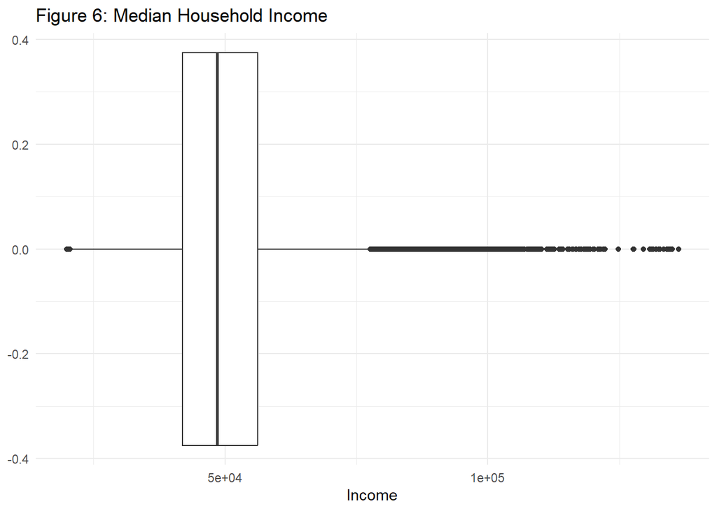

```r
ggplot(cleaned_data, aes(x = mhi_2018)) +
  geom_boxplot() +
  labs(title = "Figure 6: Median Household Income",
       x = "Income") +
  theme_minimal()
```

The boxplot of median household income provides a summary of income distribution across the dataset. This gives us an image of the wealth levels of the families surveyed, with most earning an income of around $50,000, though there are a group of outliers making over $100,000

# Section 5

## Key Findings:

Correlation between Household Income and Childcare Costs: We observed a slight positive correlation between median household income and childcare costs. This relationship suggests that higher-income families tend to incur higher childcare expenses, possibly due to opting for higher-quality or more expensive services.

Distribution of Childcare Costs: The distribution of childcare costs, both in center-based and family settings, typically centers around $100 per week, although there is considerable variability. This indicates a broad range of childcare expenses that families face, which can significantly impact their financial stability.

### Limitations

Data Constraints: Our conclusions are constrained by the data available, which may not capture all demographic groups or geographical areas comprehensively. The use of only county-level data may also mask important variations within counties.

Causal Inferences: Due to the nature of the data, our analysis is primarily correlational. As such, we cannot definitively assert causal relationships between socioeconomic factors and childcare costs.

Temporal Limitations: The data covers up to 2018, and recent economic events such as the COVID-19 pandemic may have since altered the landscape of childcare costs and economic conditions significantly.

### Future Research Directions:

Impact of Recent Economic Changes: Research could also explore the impact of recent global economic disruptions, like the COVID-19 pandemic, on childcare costs and family economics to inform current policy discussions. Qualitative Studies: Incorporating qualitative research could help capture the personal experiences and challenges families face regarding childcare, offering a more holistic view of the issue’s impact on American family life.